# Лабораторная работа №2

Операционные системы

Куокконен Д. А.

Российский университет дружбы народов, Москва, Россия

## Цель работы

Цель данной лабораторной работы – изучение идеологии и применения средств контроля версий, освоение умения по работе с git.

## Задание

1. Создать базовую конфигурацию для работы с git
2. Создать ключ SSH
3. Создать ключ GPG
4. Настроить подписи Git
5. Заргеистрироваться на GitHub
6. Создать локальный каталог для выполнения заданий по предмету.

## Выполнение лабораторной работы. Установка ПО.

Я устанавливаю необходимое программное обеспечение *git* и *gh* через терминал с помощью команд: *dnf install git* и *dnf install gh* (рис. 1).

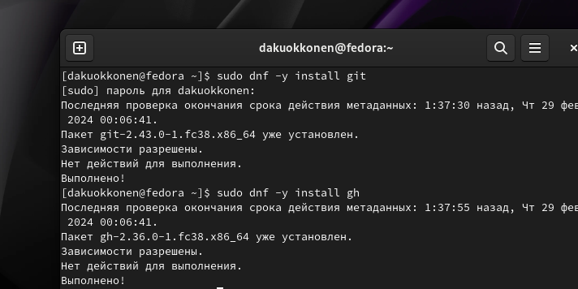

Установка git и gh

## Выполнение лабораторной работы. Базовая настройка git

Задаю в качестве имени и email владельца репозитория свои имя, фамилию и электронную почту, настраиваю *utf-8* в выводе сообщений *git* для их корректного отображения, задаю имя начальной ветке, задаю параметры *autocrlf* и *safecrlf* для корректного отображения конца строки (рис. 2).

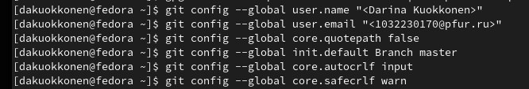

Найстройка конфига git

## Выполнение лабораторной работы. Создание ключа SSH

Создаю ключ ssh размером 4096 бит по алгоритму rsa (рис. 3).

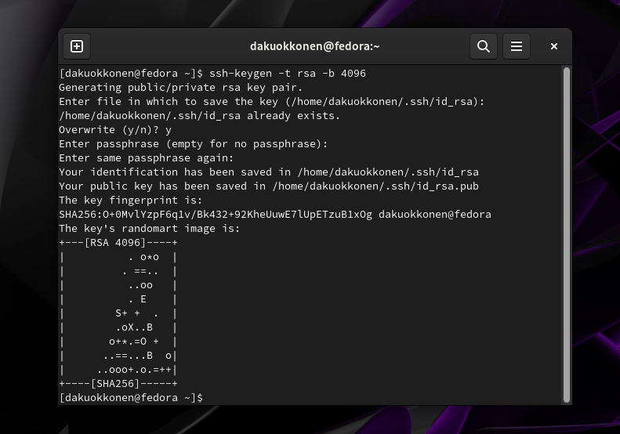

Генерация ssh ключа по алгоритму rsa

## Выполнение лабораторной работы. Создание ключа SSH

Создаю ключ ssh по алгоритму ed25519 (рис. 4).

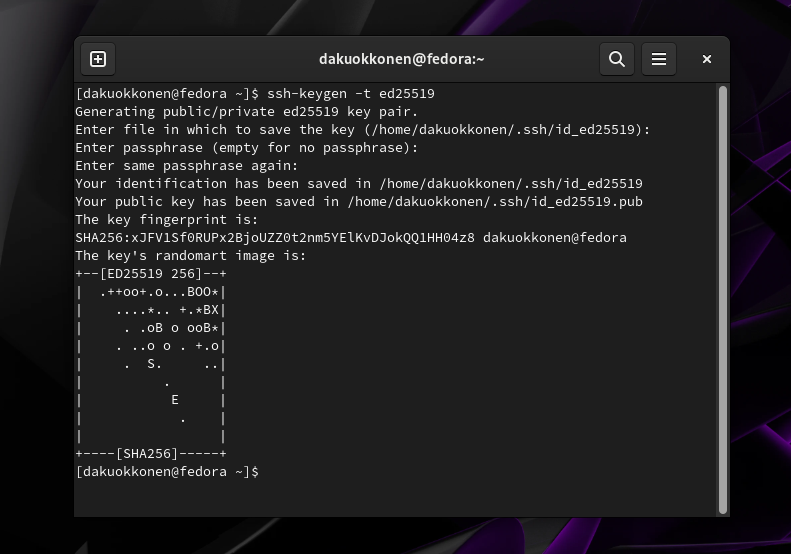

Генерация ssh ключа по алгоритму ed25519

## Выполнение лабораторной работы. Создание ключа GPG

Генерирую ключ *GPG*, затем выбираю тип ключа *RSA*, задаю максиммальную длину ключа: 4096, выбираю неограниченный срок действия ключа. Завершаем настройку (рис. 5).

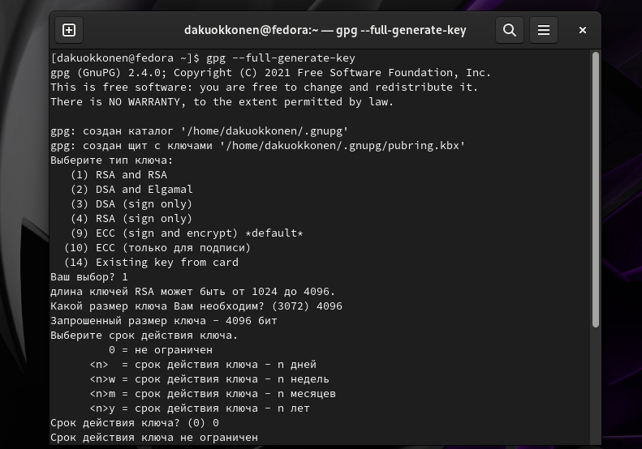

Генерация ключа

## Выполнение лабораторной работы. Регистрация на Github

Раннее у меня уже был создан аккаунт на Github, поэтому я просто вхожу в свой аккаунт.

## Выполнение лабораторной работы. Добавление ключа GPG в Github

- Вывожу список созданных ключей в терминал
- Ищу в результате запроса отпечаток ключа
- Копирую его в буфер обмена, за это отвечает утилита *xclip* (рис. 6).

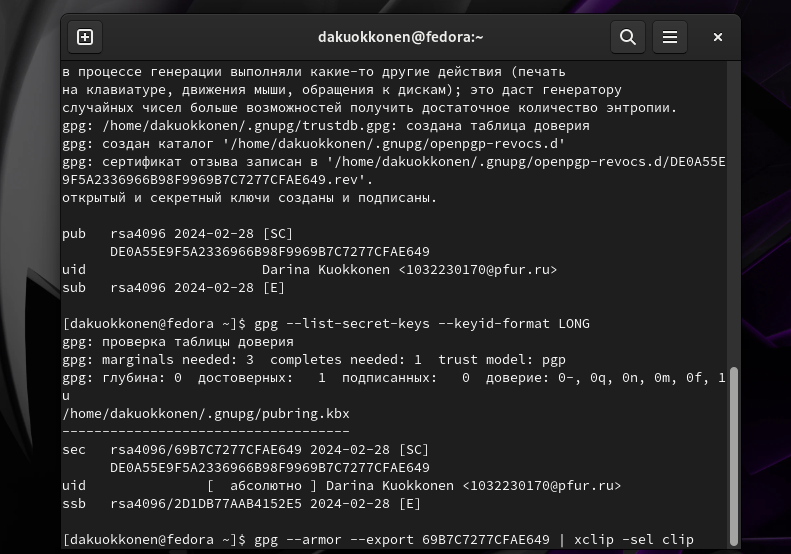

Вывод списка ключей

## Выполнение лабораторной работы. Настроить подписи Git

Настраиваю автоматические подписи коммитов *git* (рис.7).

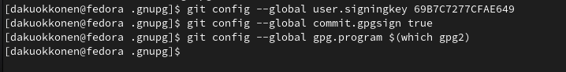

Настройка подписей Git

## Выполнение лабораторной работы. Настройка gh

- Начинаю авторизацию в gh
- отвечаю на наводящие вопросы от утилиты
- выбираю авторизоваться через браузер (рис. 8).

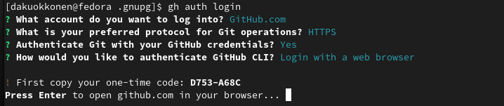

Авторизация в gh

## Выполнение лабораторной работы. Настройка gh

Завершаю авторизацию на сайте (рис. 9).

[figure not shown]

Завершение авторизации через браузер

## Выполнение лабораторной работы. Настройка gh

Вижу сообщение о завершении авторизации (рис. 10).

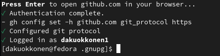

Завершение авторизации

## Выполнение лабораторной работы. Создание репозитория курса на основе шаблона

- Создаю директорию с помощью утилиты mkdir и флага -p
- Перехожу в только что созданную директорию “ОС”.
- В терминале ввожу команду gh repo create study_2023-204_os-intro –template yamadharma/course-directory-student-trmplate –public.
- После этого клонирую репозиторий к себе в директорию (рис. 11).

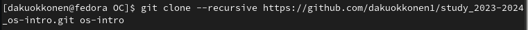

Создание репозитория

## Выполнение лабораторной работы. Создание репозитория курса на основе шаблона

Ввожу фразу-пароль, установленную ранее (рис. 12).

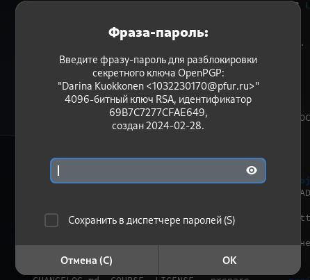

Подтверждение пароля

## Выполнение лабораторной работы. Создание репозитория курса на основе шаблона

Перехожу в каталог курса с помощью утилиты cd, там я удаляю лишние файлы с помощью утилиты rm, далее создаю необходимые каталоги используя make. В конце концов добавляю все новые файлы для отправки на сервер (сохраняю добавленные изменения) с помощью команды git add и комментирую их с помощью git commit (рис. 13).

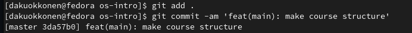

Работа с каталогами

## Выводы

При выполнении данной лабораторной работы я изучила идеологию и применение средств контроля версий, освоила умение по работе с git.

## Список литературы

1. Лабораторная работа № 2 [Электронный ресурс] URL: https://esystem.rudn.ru/mod/page/view.php?id=970819